# Cost-Effectiveness of Continuous Glucose Monitoring vs. Blood Glucose Monitoring in Non-Insulin-Treated Type 2 Diabetes

A Markov model with UKPDS-derived risk scaling, deterministic and probabilistic sensitivity analysis

Author

Said Adjao

Published

July 2, 2026

## 1 Summary

This analysis evaluates the cost-effectiveness of continuous glucose monitoring (CGM) versus blood glucose monitoring (BGM) in adults with type 2 diabetes not treated with insulin. Unlike a direct clinical-event reduction, CGM’s benefit was modeled through a surrogate pathway: an independent meta-analysis estimated CGM’s effect on HbA1c (mean difference −0.42%), scaled to a microvascular complication risk reduction using the dose-response relationship from UKPDS 35.

At a base-case annual cost of $2,500, the ICER was **$446,091 per QALY** — exceeding the US willingness-to-pay threshold and representing weaker value than a comparable direct-acting therapeutic (SGLT2 inhibitors) modeled on the same framework.

## 2 Background

CGM is a monitoring technology rather than a therapeutic agent: its value depends on translating improved glycemic visibility into better long-term outcomes via glucose control. This creates a structurally different economic case than a drug with a directly measured clinical-event benefit, and this analysis quantifies that difference explicitly.

## 3 Methods

### 3.1 From surrogate outcome to health states

CGM’s treatment effect enters the model in two steps. First, an independent meta-analysis of 8 RCTs estimated CGM’s effect on HbA1c (MD −0.42%, 95% CI −0.59 to −0.25). Second, this reduction was translated into a relative risk reduction for microvascular complications using UKPDS 35, which found each 1% absolute HbA1c reduction associated with a 37% (95% CI 33–41%) reduction in microvascular complication risk, with no observed threshold. Scaling exponentially to −0.42% yields a relative risk reduction of **17.6%**, applied to the Stable→Complication transition probability.

### 3.2 Model structure

A three-state Markov model (Stable; Complication; Dead), 20 annual cycles, 3% discounting, mirrors the structure used for the companion SGLT2 inhibitor analysis.

Base-case model inputs.

| Parameter | Value | Source |
| --- | --- | --- |
| HbA1c mean difference (CGM vs BGM) | −0.42% (95% CI −0.59, −0.25) | Meta-analysis (8 RCTs) |
| UKPDS RRR per 1% HbA1c | 37% (95% CI 33–41%) | UKPDS 35 (Stratton et al., BMJ 2000) |
| Scaled RRR at −0.42% | 17.6% | Calculated |
| Baseline complication rate (annual) | 0.030 | Illustrative |
| Background mortality (Stable) | 0.015 | Life tables |
| Mortality (Complication) | 0.025 | Illustrative |
| CGM annual cost | $2,500 | Device pricing |
| Complication annual cost | $3,000 | Costing study |
| Background care cost (Stable, annual) | $1,500 | Illustrative |
| Utility: Stable | 0.87 | Utility study |
| Utility: Complication | 0.75 | Utility study |
| Discount rate | 3% | Convention |
| Time horizon | 20 years | — |

## 4 Results

### 4.1 Base case

Base-case costs and QALYs per patient (discounted).

| Arm | Cost | QALYs |
| --- | --- | --- |
| BGM | $24,875 | 11.627 |
| CGM | $58,728 | 11.703 |
| Incremental | $33,853 | 0.076 |

Base-case ICER: **$446,091/QALY**.

### 4.2 One-way sensitivity: UKPDS relationship

ICER across the UKPDS 95% CI.

| Scenario | ICER |
| --- | --- |
| UKPDS low (33%) | $511,007 |
| Base case (37%) | $446,091 |
| UKPDS high (41%) | $393,633 |

The conclusion is unaffected across the UKPDS confidence interval.

### 4.3 One-way sensitivity: CGM price

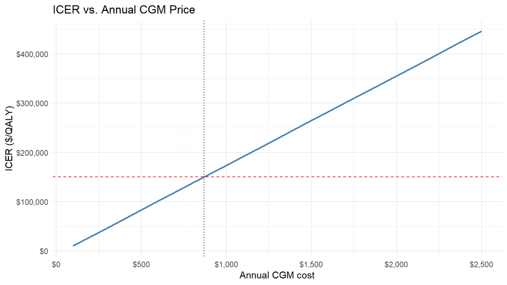

CGM reaches $150,000/QALY at an annual price of approximately **$870** — a substantially larger price reduction (from $2,500) than required for the companion SGLT2 inhibitor model, reflecting the smaller absolute benefit achievable through the surrogate pathway.

### 4.4 Probabilistic sensitivity analysis

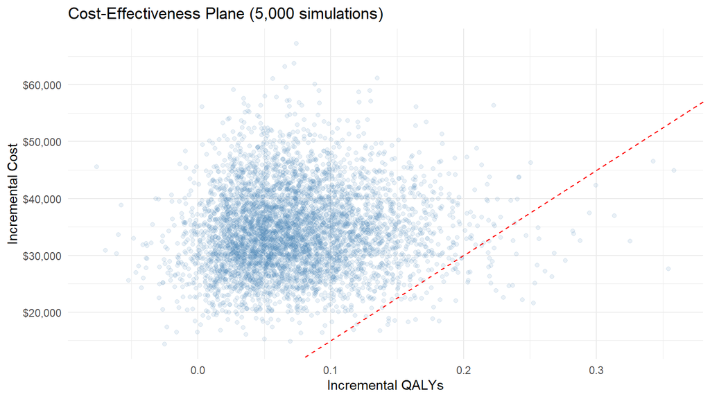

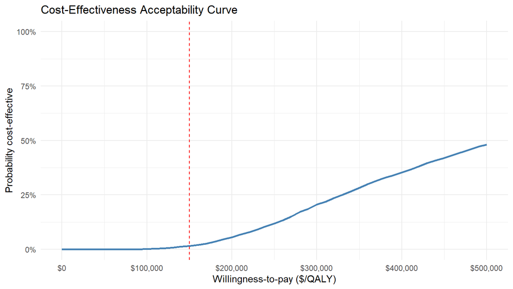

PSA probability of cost-effectiveness at $150,000/QALY: **1.54%**.

## 5 Comparison to SGLT2 inhibitors

Both interventions were modeled on the same Markov framework, but their mechanisms differ fundamentally: SGLT2 inhibitors reduce a directly measured clinical event (HF hospitalization); CGM’s benefit is mediated through a surrogate marker requiring an additional risk-translation step. This is reflected in the results — CGM’s ICER, threshold price gap, and PSA probability are all less favorable than SGLT2i’s, despite both treatment effects being statistically robust in their respective meta-analyses. This illustrates that evidentiary certainty about effectiveness does not guarantee favorable cost-effectiveness; the causal pathway’s directness materially affects economic value.

## 7 Conclusion

CGM reduces HbA1c with a well-established effect, but under base-case assumptions its cost-effectiveness for preventing microvascular complications in non-insulin-treated T2DM is substantially weaker than a comparable direct-acting therapy, driven by the indirectness of its benefit pathway rather than uncertainty in the underlying evidence.